# Modeling the Impact of a Household Carbon Tax in Argentina: A Microsimulation Exercise

Author

Priscila Stitsman, Ines Dezcallar, David Gentili and Asad Azhar

```r
#Library Setup
library(readr)
library(here)
library(tidyverse)
```

## Loading Dataset

```r
####  Household Income
hh_2018 <- read_delim(here("data","engho2018_hogares.txt"),
  delim = "|",
  col_names = FALSE,
  locale = locale(encoding = "Latin1")
)

colnames(hh_2018) <- strsplit(
  "id.provincia.region.subregion.trimestre.anio.pondera.cv1c04.cv1c05_a.cv1c05_b.cv1c05_c.cv1c05_d.cv1c06_e.cv1c06_f.cv1c07.cv1c08.cv1c09.cv1c10.cv1c11.cv1c12.cv1c13.ch01.ch02.ch03.ch04.ch05.ch06.ch07.ch08.ch09.ch10.ch11.ch12.ch13.ch14.ch15.ch16.ch17_a.ch17_b.ch18.ch19.ch20.ch21.propauto.regten.hacina.jniveled.jsexo.jedad_agrup.jsitconyugal.jdif_lp.jestado.jocupengh.jpercept.jcomed.tipohog.cantping.reldep.cantmiem.cantadequi.menor18.menor14.mayor65.dif_lph.cant_act.permieoc.clima_educativo.gastot.gastotpc.gasto_comunh.gascomp.gasvent.gc_01.gc_02.gc_03.gc_04.gc_05.gc_06.gc_07.gc_08.gc_09.gc_10.gc_11.gc_12.gc09_01.gc09_02.gc09_03.gc09_04.gc09_05.gc09_06.gc09_07.gc09_08.gc09_09.fp_contado.fp_credito.fp_especie.fp_prodprop.fp_tarjetas.fp_otras.fp_indef.tn_hipsup.tn_autoserv.tn_negesp.tn_restaurant.tn_kiosco.tn_internet.tn_comedor.tn_especie.tn_otros.tn_indef.decgaphp.decgaphr.decgapht.quigaphp.quigaphr.quigapht.gasto_imputado.m_gasto_imputado.ingtoth.ingpch.m_ingtoth.ingtoth_imp.qinth_p.qinth_r.qinth_t.dinth_p.dinth_r.dinth_t.qinpch_p.qinpch_r.qinpch_t.dinpch_p.dinpch_r.dinpch_t",
  "\\."
)[[1]]

# Count of missing values in each column
#colSums(is.na(hh_2018))

# First rows as colnames
colnames(hh_2018) <- as.character(unlist(hh_2018[1, ]))
hh_2018 <- hh_2018[-1, ]
hh_2018 <- type.convert(hh_2018, as.is = TRUE)

##### Household Expenditure

gastos <- read_delim((here("data",
                           "engho2018_gastos.txt")),
                     delim = "|",
                     locale = locale(encoding = "Latin1"))
##### Codebook

codes <- read_delim(here("data",
  "engho2018_articulos.txt"),
  delim = "|",
  locale = locale(encoding = "Latin1")
)
```

## Cleaning & Wrangling Data

```r
########################################################
##### Energy expenditure: electricity, gas, others #####
########################################################


energy_exp <- gastos %>%
  filter(articulo %in% c("A0451101", "A0451102", "A0451103",
                         "A0452101", "A0452102", "A0452103",
                         "A0452104", "A0452105",
                         "A0453101", "A0453102", "A0453103")) %>%
  mutate(articulo_label = case_when(
    articulo == "A0451101" ~ "Electricidad - vivienda principal",
    articulo == "A0451102" ~ "Electricidad - vivienda secundaria",
    articulo == "A0451103" ~ "Gastos de electricidad realizados para una vivienda ocupada por otro hogar",
    articulo == "A0452101" ~ "Gas envasado en garrafas",
    articulo == "A0452102" ~ "Gas a granel",
    articulo == "A0452103" ~ "Gas natural - vivienda principal",
    articulo == "A0452104" ~ "Gas envasado en tubo",
    articulo == "A0452105" ~ "Gas natural - vivienda secundaria",
    articulo == "A0453101" ~ "Kerosene",
    articulo == "A0453102" ~ "Leña y carbón",
    articulo == "A0453103" ~ "Otros combustibles para el hogar",
    TRUE ~ "Otro"
  ))


###########################
##### Household Income ####
###########################

income_hh <- hh_2018 %>% select(id, ingtoth, ingpch)


## Merging household income with expenditure in energy

carbon_tax <- energy_exp %>%
  left_join(income_hh %>% select(id, ingtoth), by = "id") %>%
  select (-miembro, -subclase, -clase, -grupo, -division, -forma_pago, -modo_adq, -lugar_adq, -tipo_negocio)
```

```r
subregion_labels <- c(
  "1A" = "CABA",
  "1B" = "GBA",
  "2A" = "Córdoba y La Pampa",
  "2B" = "Santa Fe y Entre Ríos",
  "2C" = "Buenos Aires (resto)",
  "3A" = "Jujuy, Salta y Tucumán",
  "3B" = "La Rioja, Catamarca y Santiago del Estero",
  "4A" = "Misiones y Corrientes",
  "4B" = "Chaco y Formosa",
  "5"  = "Cuyo (San Juan, Mendoza y San Luis)",
  "6A" = "Neuquén y Río Negro",
  "6B" = "Chubut, Santa Cruz y Tierra del Fuego"
)
```

## Introduction

#### Motivation

With 394.76 million tonnes of CO₂ emitted in 2021, Argentina accounts for approximately 0.83% of global emissions (**climatewatch2025?**). Although not a major polluter, the government implemented a tax reform in 2017 that included the introduction of a carbon tax through the amendment of Law No. 23.966. As a result, Argentina is one of the few Latin American countries with a carbon tax, alongside Colombia, Chile, Mexico, and Uruguay. This reform aligns with a growing global trend toward carbon taxation.

Carbon taxes are increasingly seen as a crucial tool to drive environmental sustainability by reducing greenhouse gas emissions. There are indeed, a cost-effective means of reducing emissions compared to command-and-control regulations or subsidies (**gugler2021?**). As a Pigouvian tax, carbon pricing helps internalize the external costs of carbon emissions, creating incentives for households to adjust their energy consumption behavior toward cleaner alternatives.

However, literature suggests that they can be regressive, disproportionately burdening lower-income households. This is particularly concerning given the global push toward ecological transition and sustainability. As countries implement carbon tax policies to meet their climate goals, it is essential to assess their potential socioeconomic impacts. Understanding how various income groups will be affected is critical to ensuring that the transition to a sustainable economy is both fair and inclusive. A well-designed policy can help mitigate the risk of exacerbating inequality, ensuring that environmental goals are achieved without disproportionately harming vulnerable populations.

#### Objective

To evaluate the distributional impact and policy design trade-offs of implementing a household-level carbon tax in Argentina, using a microsimulation model based on household energy expenditure data and carbon pricing structures from Argentina and added policies from developed countries.

#### Context

Carbon taxes are difficult to design, as they involve the complex task of putting a price on emissions and valuing different sources of carbon dioxide emissions differently. There are many ways to approach this, which is why carbon taxes are regulated in a variety of ways across countries. For the purposes of our microsimulation, we will consider three different carbon tax models, drawing primarily from two countries. We will take inspiration from the Argentinian model, as well as from Canada, which has implemented a more aggressive carbon tax system.

In 2017, Macri’s government introduced a carbon tax, layered on top of an existing tax on liquid fuels. The carbon tax consists of fixed lump sums per unit volume of each fuel, adjusted for inflation every quarter and varying according to the carbon dioxide (CO₂) emissions associated with each fossil fuel. The government planned a gradual increase in the tax rate, an annual 10% hike from 2019 to 2028 (**méxico2-plataformamexicanadecarbono2023?**). As of 2023, the carbon price resulting from these increases corresponded to approximately USD 10 per ton of CO₂ (USD 10/tCO₂) (**méxico2-plataformamexicanadecarbono2023?**). Tax rates are relatively low compared to the what is advised by the IMF, which sets the floor for middle-income countries at USD 50/tCO₂ (**economiccommissionforlatinamericaandthecaribbean2025?**), but higher than in regional peers such as Chile, Colombia, and Mexico. The tax is applied upstream, targeting fuel importers and producers, rather than directly to households. Its design resembles that of a typical Pigouvian tax.

On the other hand, Canada has a dual carbon pricing system, consisting of a federal fuel charge and a separate system for large industrial emitters. The federal fuel charge is applied to producers, importers, and distributors of fossil fuels, as well as other CO₂-emitting entities such as air and marine carriers [(**canadarevenueagency2022?**)][.](https://www.canada.ca/en/revenue-agency/services/tax/excise-taxes-duties-levies/fuel-charge/registration.html)Although the charge is levied upstream, it is often passed on to consumers.

As of April 2025, the federal fuel charge has been discontinued, but its structure will inform the design of this microsimulation (**canadaenvironmentandclimatechange2018?**). Like Argentina, Canada sets specific charges for specific fuel types (**canadadepartmentoffinance2025?**). However, each province is allowed to implement a higher carbon price than the federal benchmark. Other countries, such as Mexico, also apply differentiated carbon taxes across regions.

Compared to Argentina, Canada enforces a higher and more uniform carbon price (approximately $50/tCO₂e). Additionally, with the exception of the Yukon and Nunavut territories, Canada provides direct lump-sum rebates to households through the Canada Carbon Rebate scheme. These rebates are adjusted based on family size, rural residence, and province, helping to offset the increase in living costs resulting from the carbon tax. This model offers a valuable benchmark for balancing equity and efficiency in carbon pricing policy design.

Moreover, energy sources are not uniform across regions in Argentina. By 2017–2018—the latest available data and the year Argentina introduced a minor carbon tax—an energy subsidy system was in place based on household income and geographic location (province). Subsidies applied to both electricity and natural gas.

Under the 2018 segmentation scheme, residential users were divided into three categories:

- N1 (High income): Pay the full cost of energy.
- N2 (Low income): Receive full subsidies (tarifa social).
- N3 (Middle income): Receive partial subsidies with a consumption cap.

How Final Energy Prices Are Determined Energy bills in Argentina reflect four main components:

Energy generation price – set nationally and uniform across the country. Transmission costs – for transporting energy to distributors. Distribution costs (VAD) – set by local distributors and vary by province/municipality. Taxes – national, provincial, and municipal. Thus, the final price a household pays depends on:

Income level and subsidy eligibility, and The specific distribution and tax rates set by their province or municipality. Electricity vs. Gas Regulation Electricity distribution is decentralized and regulated by provinces and municipalities, except in the Buenos Aires Metropolitan Area (AMBA), where it’s under national jurisdiction. Gas distribution remains under national regulation, managed by ENARGAS, with prices differentiated by service zones and subzones. While the generation cost is the same nationwide, the final bill varies significantly due to differences in local distribution charges (VAD) and regional tax burdens.

## Microsimulation Model Structure

#### Basic Microsimulation Model

Our basic model will have the following characteristics:

- Use microdata from Argentina’s national household expenditure survey (Encuesta Nacional de Gastos de los Hogares, ENGHo) to estimate baseline household spending on energy sources (**indec:institutonacionaldeestadísticaycensosdelarepúblicaargentina2018?**).
- Apply carbon price increases to each energy source using the official carbon content conversion table (from Argentina’s and Canada’s tax authority).
- Model price pass-through to consumers under the assumption that households ultimately bear the tax burden through higher energy prices.mi

As such we have created three basic model that try to emulate three different carbon taxation systems:

- A first model that simulates a uniform tax across all households and no inclusion of behavioral response or rebates.
- A second model that attempts to mimic the Argentinean carbon tax as it is regulated with lump sums instead of tax rates, also with no behavioral response or rebates.
- A third model that includes variation in tax rates depending on how pollutant the energy source used is mimicking the standards from Canada. In this third model we include variations in tax rates by energy type, behavioral response through elasticity, and the inclusion of different schemes of rebates.

#### Data Description

In the data frame we have constructed basing ourselves on the 2018 household survey, we have information covering 21,065 households, identified by the variable “id”. The data was collected between November of 2017 and November of 2018.

Our data includes spending per household, as well as quantity consumed per household, on the following energy sources:

- Bottled gas / LPG in canisters (Gas envasado en garrafas)
- Bulk-delivered LPG (Gas a granel)
- Gas in larger cylinders or tanks (Gas envasado en tubo)
- Markatable Natural Gas (Gas Natural)
- Electricity (Electricidad)
- Kerosene
- Other liquid fossil fuels (Otros combustibles)
- Coal and fuelwood (Leña y Carbón)

#### Sensitivity Analysis

Building on the third model, we will perform a sensitivity analysis that tests multiple scenarios using alternative parameter values.

##### Elasticity Analysis

Building on our third model, we will examine how higher carbon prices reshape household demand for key energy sources. (Zabaloy and Viego 2022) report short-run price elasticities ranging from –0.09 (highly inelastic) to –0.76 (more responsive). We adopt the upper-level magnitude of –0.76 for two reasons. First, several household fuels in the study—notably firewood, kerosene, and bottled gas—cluster near this more elastic estimate, so –0.76 offers a realistic benchmark for those segments of Argentina’s energy mix that can, in practice, be switched or curtailed. Second, using the most elastic value gives us an upper-bound scenario: it reveals the maximum plausible demand response and helps policymakers gauge the ceiling on emissions reductions, revenue volatility, and distributional impacts if households react more aggressively than the historical average. Third, the –0.76 elasticity is forward-looking.

##### Different Carbon Price Levels

We will apply different tax rates to different energy types.

##### Distributional Analysis

Furthermore, we will evaluate the impact of carbon taxes as set forth on our three initial model on income distribution. In order to do that will first estimate the post-tax energy expenditures for each household, and then estimate the impact on the tax income and income distribution per income quintiles.

We will evaluate revenue recycling mechanisms through cash transfers:

- Flat per capita rebate (uniform transfer to all)
- Progressive rebate (Enhanced rebates for lower-income households.
- Compare net distributional impacts: tax paid minus rebate received.

## Microsimulations

### Model I: A uniform tax across all households

#### Model

```r
#Suppose we add a 10% tax on the price paid by all households. What would be the final amount paid, the income effect and revenue effect?

# Build function to calculate carbon tax of 10%
calculate_carbon_tax <- function(monto) {
  tax <- monto * 0.10
  return(tax)
}

# Apply function to dataframe
carbon_tax_I <- carbon_tax %>%
  mutate(
    carbon_tax = map_dbl(
      .x = monto, #apply the function to every value of the column "monto"
      .f = calculate_carbon_tax
    ),
    # Calcular el ingreso neto después del impuesto
    net_income = ingtoth - carbon_tax
  )

# Calculate quintiles
carbon_tax_I <- carbon_tax_I %>%
  # Creamos una variable de decil basada en el ingreso total
  mutate(
    quintile = ntile(ingtoth, 5)
  )

# Avg values by quintile
quintile_averages <- carbon_tax_I %>%
  group_by(quintile) %>%
  summarise(
    avg_total_income = mean(ingtoth, na.rm = TRUE),
    avg_net_income = mean(net_income, na.rm = TRUE),
    avg_tax = mean(carbon_tax, na.rm = TRUE),
    # Calcular el porcentaje que representa el impuesto del ingreso total
    tax_percentage = mean(carbon_tax/ingtoth * 100, na.rm = TRUE)
  )



# Pivot long for plotting
plot_data <- quintile_averages %>%
  select(quintile, avg_total_income, avg_net_income) %>%
  pivot_longer(
    cols = c(avg_total_income, avg_net_income),
    names_to = "income_type",
    values_to = "value"
  )
```

#### Output

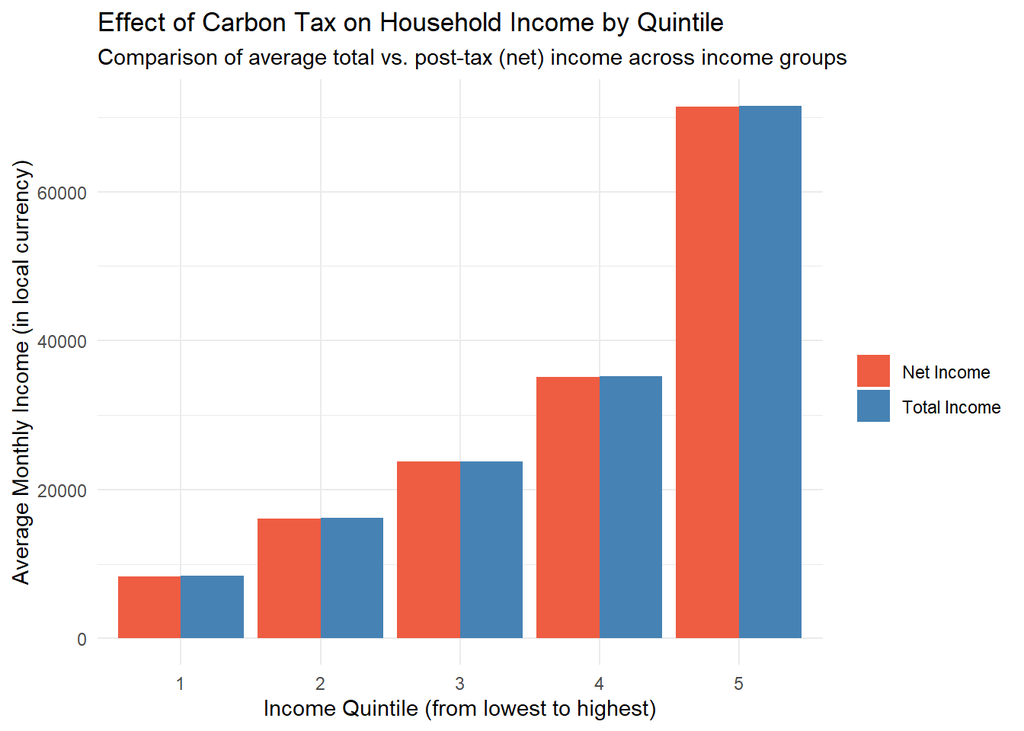

```r
### OUTPUTS

# $Income – $energy spend: How much income increases or decreases before and after by quintile.

income_plot_model1 <- ggplot(plot_data, aes(x = factor(quintile), y = value, fill = income_type)) +
  geom_bar(stat = "identity", position = position_dodge()) +
  scale_fill_manual(
    values = c("avg_total_income" = "steelblue", "avg_net_income" = "tomato2"),
    labels = c("avg_total_income" = "Total Income", "avg_net_income" = "Net Income")
  ) +
  labs(
    title = "Effect of Carbon Tax on Household Income by Quintile",
    subtitle = "Comparison of average total vs. post-tax (net) income across income groups",
    x = "Income Quintile (from lowest to highest)",
    y = "Average Monthly Income (in local currency)",
    fill = ""
  ) +
  theme_minimal()

print(income_plot_model1)
```

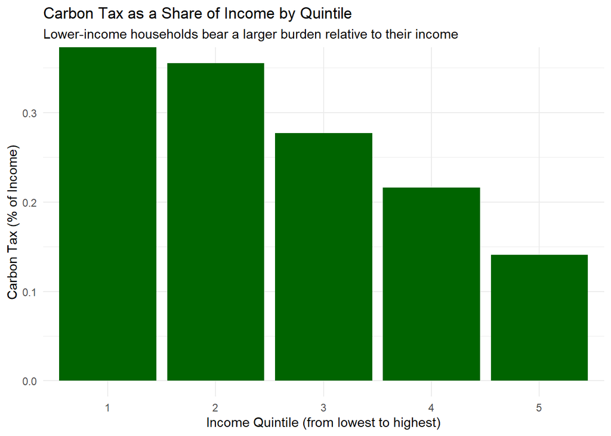

```r
# Relative Tax Burden
tax_burden_plot_model1 <- ggplot(quintile_averages, aes(x = factor(quintile), y = tax_percentage)) +
  geom_bar(stat = "identity", fill = "darkgreen") +
  labs(
    title = "Carbon Tax as a Share of Income by Quintile",
    subtitle = "Lower-income households bear a larger burden relative to their income",
    x = "Income Quintile (from lowest to highest)",
    y = "Carbon Tax (% of Income)"
  ) +
  theme_minimal()

print(tax_burden_plot_model1)
```

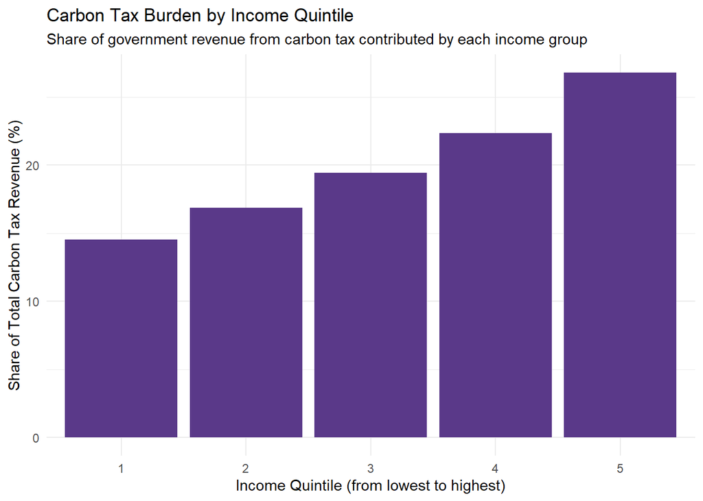

```r
#Revenue collected by the government
tax_by_quintile <- carbon_tax_I %>%
  group_by(quintile) %>%
  summarise(
    total_tax = sum(carbon_tax, na.rm = TRUE)
  ) %>%
  ungroup() %>%
  mutate(
    total_revenue = sum(total_tax),
    tax_share = total_tax / total_revenue * 100  # proporción pagada por cada quintil
  )

#Contribution by quintile
tax_share_plot_model1 <- ggplot(tax_by_quintile, aes(x = factor(quintile), y = tax_share)) +
  geom_bar(stat = "identity", fill = "#5A3989") +
  labs(
    title = "Carbon Tax Burden by Income Quintile",
    subtitle = "Share of government revenue from carbon tax contributed by each income group",
    x = "Income Quintile (from lowest to highest)",
    y = "Share of Total Carbon Tax Revenue (%)"
  ) +
  theme_minimal()

print(tax_share_plot_model1)
```

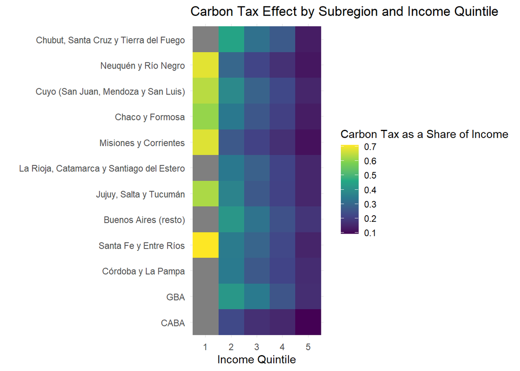

```r
## Geographic Analysis

subregion_quintile <- carbon_tax_I %>%
  group_by(subregion, quintile) %>%
  summarise(
    avg_tax_pct = mean(carbon_tax / ingtoth * 100, na.rm = TRUE),
    .groups = "drop"
  )

subregion_model1 <- ggplot(subregion_quintile, aes(x = factor(quintile), y = subregion, fill = avg_tax_pct)) +
  geom_tile() +
  scale_y_discrete(labels = subregion_labels) +
  scale_fill_viridis_c() +
  labs(title = "Carbon Tax Effect by Subregion and Income Quintile",
       x = "Income Quintile",
       y = "",
       fill = "Carbon Tax as a Share of Income") +
  theme_minimal()

print(subregion_model1)
```

### Model II: Tax varies according to energy source, with more pollutant sources with higher taxes, and is consistent with lump sums established by the Argentinian Government.

In this second version of the model, we aim to create a microsimulation that more closely reflects the carbon taxation system currently in place in Argentina.

- Under Argentina’s carbon tax, only a limited number of fossil fuels are taxed. These include:
- Unleaded naphtha, up to 92 RON (per litre)
- Unleaded naphtha, more than 92 RON (per litre)
- Virgin naphtha (per litre) Petroleum solvent (per litre)
- White spirit (per litre) Gas oil (per litre)
- Diesel oil (per litre) Kerosene (per litre)
- Petroleum coke (per kilogram)
- Coal (per kilogram)

Among the energy sources used at the household level, only two fall under this taxation scheme: kerosene and the broad category “other liquid fossil fuels.” For these two, we have data on the quantities (in litres) consumed by each household.

This approach is admittedly imperfect, as it does not account for the share of electricity generated from fossil fuels, notably, coal, which should, in principle, also be subject to carbon taxation. As we don’t know the amounts of these energy sources used to generated that a given amount of electricity, we cannot include them in this model.

As a result, a portion of households will remain untaxed in the model, even though their actual energy consumption would indirectly fall under the carbon tax in real life.

#### Model

```r
# Build function to calculate differentiated carbon tax rates based on the energy source

  calculate_carbon_tax <- function(cantidad, articulo) {

   lump_sums <- case_when(

    #Only Kerosene and Ohter liquid fossil fuels

        articulo == "A0453101" ~ mean(0.473, 0.505, 0.549, 0.626),  # Kerosene

        articulo == "A0453103" ~ mean( 0.412, 0.440, 0.478, 0.545, 0.412, 0.440, 0.478, 0.545,0.412, 0.440, 0.478, 0.545,0.412, 0.440, 0.478, 0.545,0.412, 0.440, 0.478, 0.545,0.412, 0.505, 0.549, 0.545, 0.473, 0.505, 0.549, 0.626, 0.473, 0.505, 0.549, 0.626), #Otros Combustibles

         TRUE ~ 0
  )

  # Calculate tax
  tax <- cantidad * lump_sums
  return(tax)
}
```

```r
# Step 1: calculate tax by energy type
carbon_tax_II <- carbon_tax %>%
  mutate(
    carbon_tax_item = map2_dbl(
      .x = cantidad,
      .y = articulo,
      .f = calculate_carbon_tax
    ),
    # original price paid
    price = monto/cantidad,
    # per unit markup after tax
    tax_per_unit = carbon_tax_item/cantidad,
    # Effective tax rate
    tax_rate = tax_per_unit / price
  )
```

```r
# Step 2: Total tax paid by household
household_tax_II <- carbon_tax_II %>%
  group_by(id) %>%
  summarise(
    total_carbon_tax = sum(carbon_tax_item, na.rm = TRUE),
    ingtoth = first(ingtoth)  # Take the first income by id (it is the same for each id)
  ) %>%
  mutate(
    net_income = ingtoth - total_carbon_tax
  )
```

```r
# Step 3: Calculate quintiles based on income
household_tax_II <- household_tax_II %>%
  mutate(
    quintile = ntile(ingtoth, 5)
  )
```

```r
# Step 4: Analyzing income
quintile_analysis_II <- household_tax_II %>%
  group_by(quintile) %>%
  summarise(
    avg_total_income = mean(ingtoth, na.rm = TRUE),
    avg_net_income = mean(net_income, na.rm = TRUE),
    avg_tax = mean(total_carbon_tax, na.rm = TRUE),
    avg_tax_burden = mean(total_carbon_tax/ingtoth * 100, na.rm = TRUE)
  )

carbon_tax_with_quintile_II <- carbon_tax_II %>%
  left_join(
    household_tax_II %>% select(id, quintile, total_carbon_tax),
    by = "id"
  )
```